# Air Quality in Marginalized Communities

## Borough Analysis

First off, we have Manhattan. The difficulty with this one is that Manhattan seems to tell a different story regarding where PM2.5 is more of a problem. Rather than marginalized communities (in this case, Harlem), PM2.5 is more common in business districts and tourist attractions such as Midtown Manhattan, where we’ll find some of the most popular destinations, like Times Square, or Broadway.

```r
mod_manhattan <- lm(mean ~ year + crime_all_rt + crime_viol_rt + hpi_al + lp_all + med_r_4f + med_r_cn + pct_prof_ela + pct_prof_math + pfn_fam14condo + priv_evic_amt_sought_med_adj + priv_evic_filings + volume_al + volume_cn + population_density, data = Demo2.5, subset = (Geo.Join.ID<120))
mod_manhattan_clean <- mod_manhattan$model[-10,]
mod_manhattan_clean <- lm(mean ~ ., data = mod_manhattan_clean)
summary(mod_manhattan)
```

```
##
## Call:
## lm(formula = mean ~ year + crime_all_rt + crime_viol_rt + hpi_al +
##     lp_all + med_r_4f + med_r_cn + pct_prof_ela + pct_prof_math +
##     pfn_fam14condo + priv_evic_amt_sought_med_adj + priv_evic_filings +
##     volume_al + volume_cn + population_density, data = Demo2.5,
##     subset = (Geo.Join.ID < 120))
##
## Residuals:
##      Min       1Q   Median       3Q      Max
## -0.88207 -0.21873  0.00454  0.21273  1.62787
##
## Coefficients:
##                                Estimate Std. Error t value Pr(>|t|)
## (Intercept)                   3.585e+01  2.698e+00  13.286  < 2e-16 ***
## year                         -1.477e-03  1.816e-04  -8.136 3.62e-11 ***
## crime_all_rt                  5.782e-02  7.858e-03   7.359 7.31e-10 ***
## crime_viol_rt                -1.378e-01  5.667e-02  -2.432 0.018105 *
## hpi_al                       -3.677e-03  1.182e-03  -3.112 0.002883 **
## lp_all                        8.568e-04  3.882e-03   0.221 0.826105
## med_r_4f                     -2.206e-07  6.193e-08  -3.562 0.000744 ***
## med_r_cn                     -7.535e-08  1.566e-07  -0.481 0.632330
## pct_prof_ela                  1.160e-02  1.701e-02   0.682 0.497838
## pct_prof_math                 1.555e-03  1.597e-02   0.097 0.922748
## pfn_fam14condo                5.879e-03  1.275e-03   4.609 2.27e-05 ***
## priv_evic_amt_sought_med_adj -5.605e-05  1.766e-05  -3.175 0.002400 **
## priv_evic_filings            -5.067e-05  4.413e-05  -1.148 0.255625
## volume_al                    -1.419e-02  3.117e-03  -4.553 2.76e-05 ***
## volume_cn                     1.323e-02  3.161e-03   4.187 9.74e-05 ***
## population_density            6.574e-03  4.032e-03   1.630 0.108472
## ---
## Signif. codes:  0 '***' 0.001 '**' 0.01 '*' 0.05 '.' 0.1 ' ' 1
##
## Residual standard error: 0.438 on 58 degrees of freedom
##   (82 observations deleted due to missingness)
## Multiple R-squared:  0.931,  Adjusted R-squared:  0.9132
## F-statistic: 52.19 on 15 and 58 DF,  p-value: < 2.2e-16
```

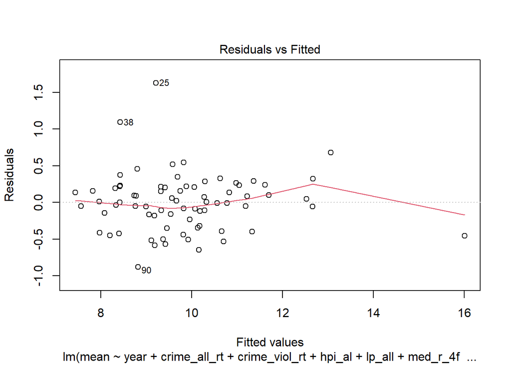

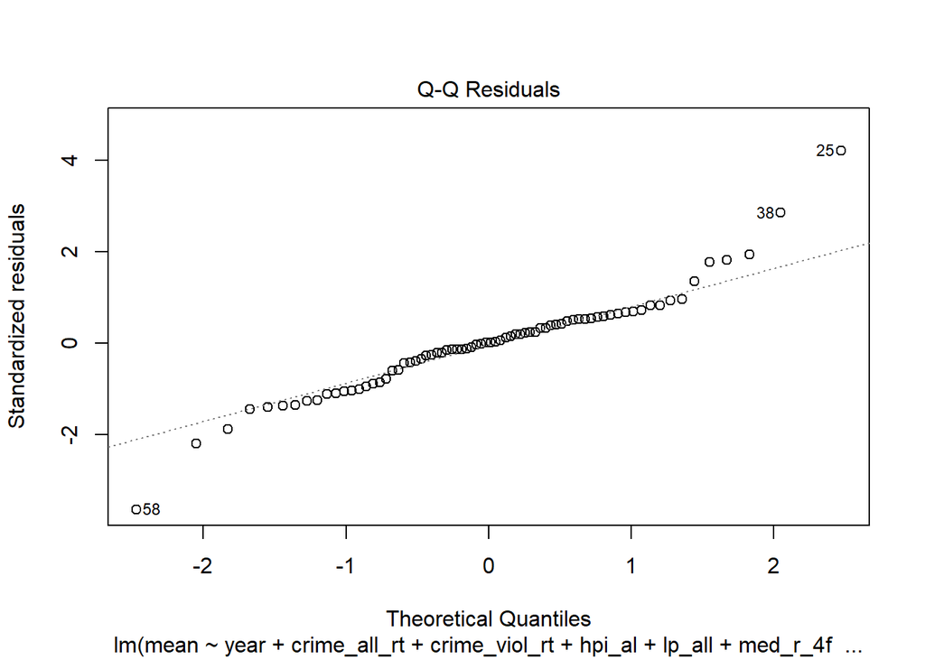

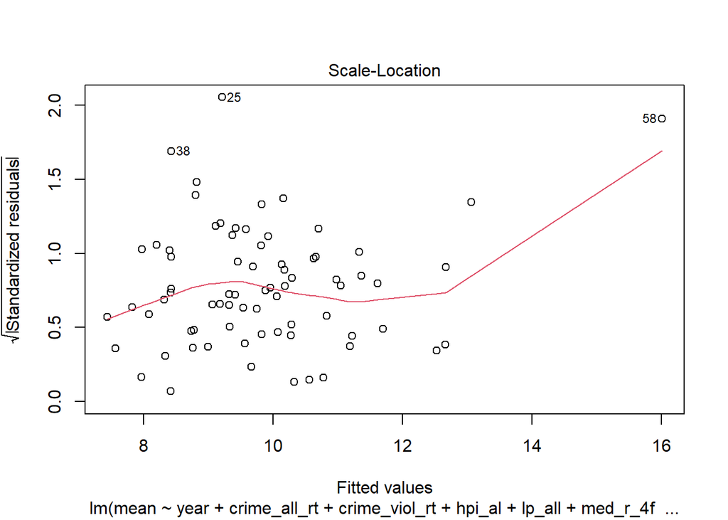

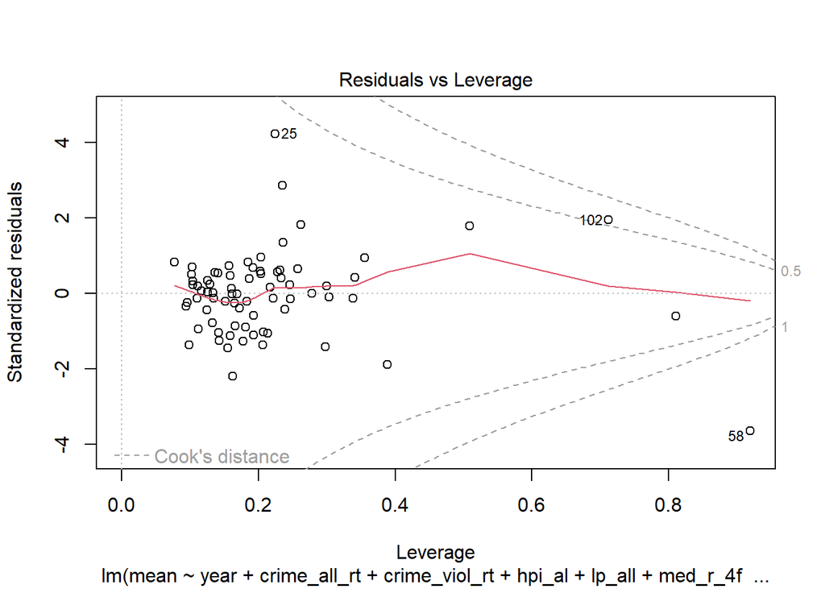

```r
plot(mod_manhattan)
```

```r
mod_bronx <- lm(mean ~ year + crime_all_rt + crime_prop_rt + crime_viol_rt + hpi_1f + hpi_al + hpi_cn + lp_all + med_r_1f + med_r_4f + med_r_cn + med_r_ot + pct_prof_ela + pfn_fam14condo + pfn_fam14condo_rate + priv_evic_amt_sought_med_adj + priv_evic_filing_rt + priv_evic_filings + total_viol_rate + volume_1f + volume_cn, data = Demo2.5, subset = (Geo.Join.ID > 200 & Geo.Join.ID < 220))
summary(mod_bronx)
```

```
##
## Call:
## lm(formula = mean ~ year + crime_all_rt + crime_prop_rt + crime_viol_rt +
##     hpi_1f + hpi_al + hpi_cn + lp_all + med_r_1f + med_r_4f +
##     med_r_cn + med_r_ot + pct_prof_ela + pfn_fam14condo + pfn_fam14condo_rate +
##     priv_evic_amt_sought_med_adj + priv_evic_filing_rt + priv_evic_filings +
##     total_viol_rate + volume_1f + volume_cn, data = Demo2.5,
##     subset = (Geo.Join.ID > 200 & Geo.Join.ID < 220))
##
## Residuals:
##      Min       1Q   Median       3Q      Max
## -0.33971 -0.16102 -0.00679  0.10755  0.34746
##
## Coefficients:
##                                Estimate Std. Error t value Pr(>|t|)
## (Intercept)                   2.614e+01  3.286e+00   7.956 9.07e-10 ***
## year                         -1.060e-03  1.778e-04  -5.963 5.32e-07 ***
## crime_all_rt                  1.248e+00  7.087e-01   1.762 0.085772 .
## crime_prop_rt                -1.093e+00  7.152e-01  -1.528 0.134269
## crime_viol_rt                -1.354e+00  7.073e-01  -1.914 0.062842 .
## hpi_1f                       -7.924e-04  1.713e-03  -0.463 0.646155
## hpi_al                        5.823e-03  2.261e-03   2.575 0.013823 *
## hpi_cn                       -2.824e-03  9.974e-04  -2.832 0.007215 **
## lp_all                       -1.767e-03  7.463e-04  -2.368 0.022788 *
## med_r_1f                      1.150e-08  7.603e-07   0.015 0.988007
## med_r_4f                     -2.902e-06  2.568e-06  -1.130 0.265076
## med_r_cn                      7.894e-07  5.991e-07   1.318 0.195127
## med_r_ot                     -2.990e-06  1.978e-06  -1.512 0.138402
## pct_prof_ela                 -2.212e-02  1.282e-02  -1.724 0.092347 .
## pfn_fam14condo                4.520e-04  2.818e-04   1.604 0.116677
## pfn_fam14condo_rate           1.096e-02  3.006e-03   3.646 0.000760 ***
## priv_evic_amt_sought_med_adj  2.258e-04  3.580e-04   0.631 0.531791
## priv_evic_filing_rt           1.600e-03  3.196e-03   0.501 0.619422
## priv_evic_filings            -1.419e-04  5.492e-05  -2.584 0.013522 *
## total_viol_rate              -1.003e-03  7.924e-04  -1.266 0.212947
## volume_1f                    -4.457e-03  1.972e-03  -2.259 0.029373 *
## volume_cn                     4.081e-03  1.008e-03   4.049 0.000229 ***
## ---
## Signif. codes:  0 '***' 0.001 '**' 0.01 '*' 0.05 '.' 0.1 ' ' 1
##
## Residual standard error: 0.2303 on 40 degrees of freedom
##   (94 observations deleted due to missingness)
## Multiple R-squared:  0.9664, Adjusted R-squared:  0.9487
## F-statistic: 54.77 on 21 and 40 DF,  p-value: < 2.2e-16
```

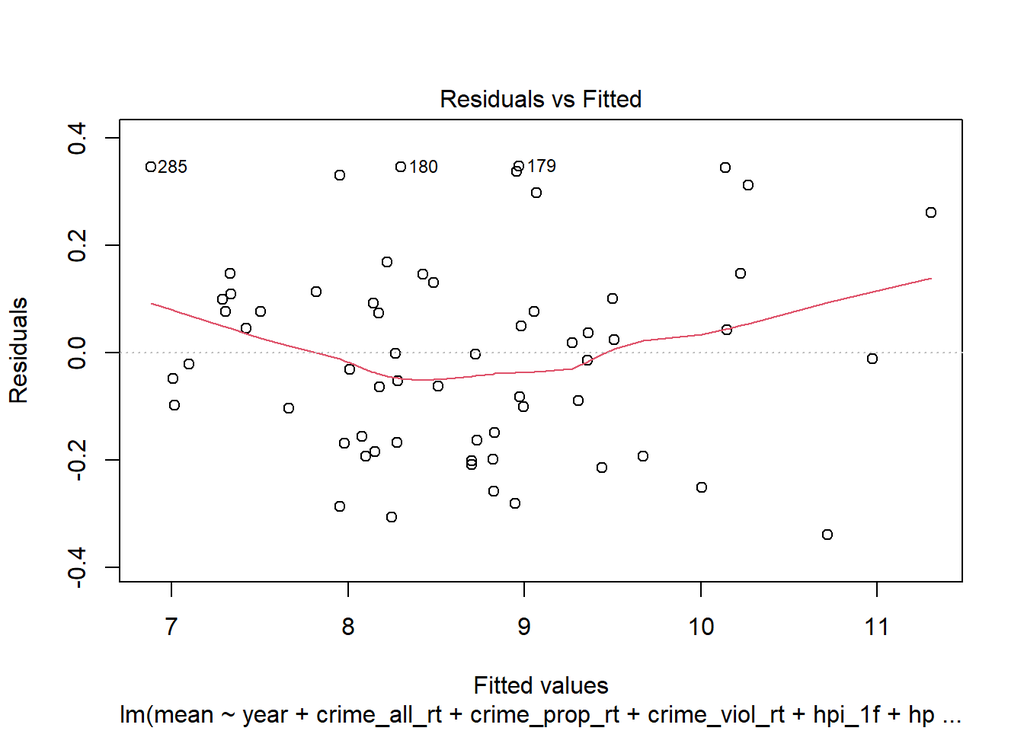

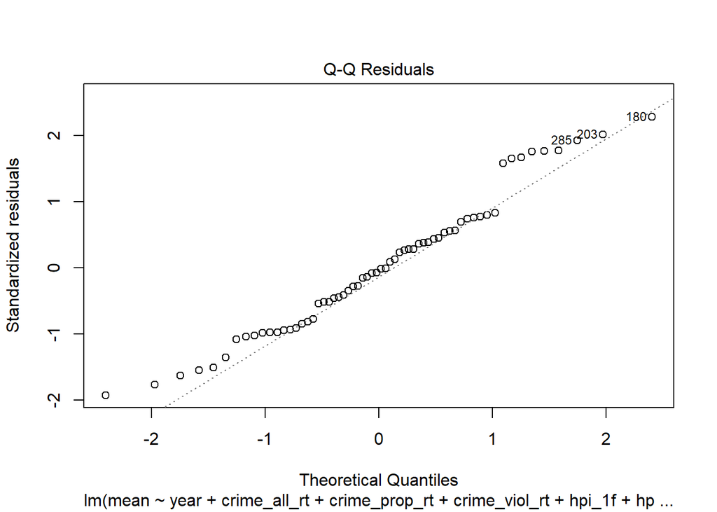

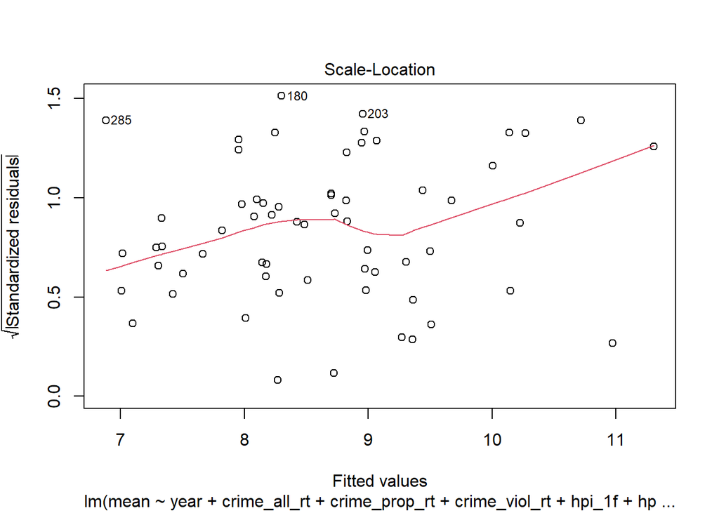

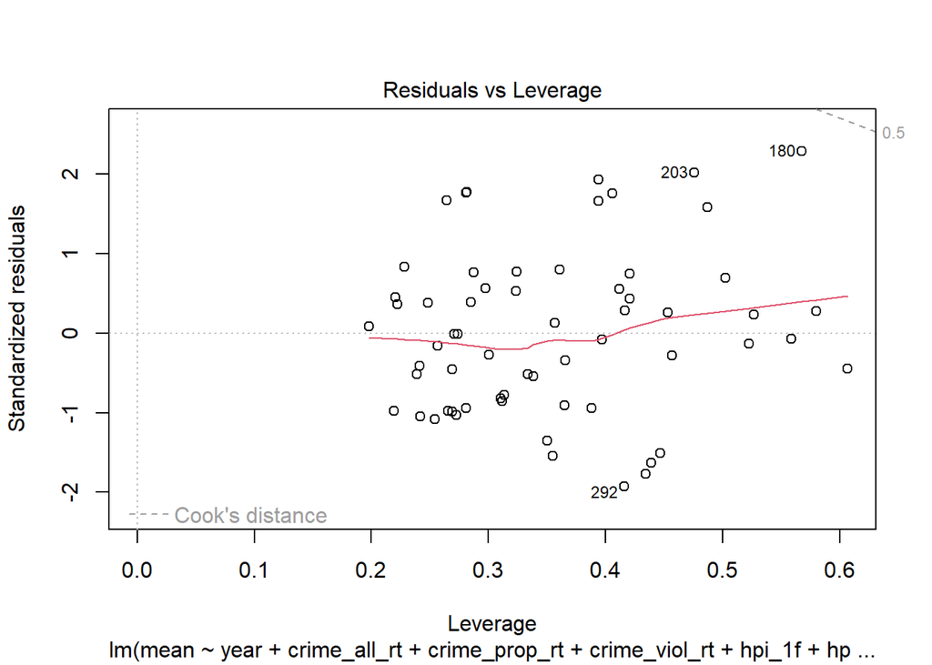

```r
plot(mod_bronx)
```

Brooklyn appears to be the most normal of the five boroughs. This could partially be due to the fact that it has 18 districts, thus, making it easier for the data to come together as a whole.

```r
mod_brooklyn <- lm(mean ~ crime_prop_rt + hpi_1f + hpi_4f + lp_fam14condo_rate + lp_fam14condo_repeat + med_r_1f + med_r_4f + med_r_ot + pct_prof_ela + pct_prof_math + pfn_fam14condo_rate + priv_evic_amt_sought_med_adj + priv_evic_filing_rt + priv_evic_filings + total_viol_rate + volume_1f + volume_4f + volume_al + volume_cn + population_density, data = Demo2.5, subset = (Geo.Join.ID > 300 & Geo.Join.ID < 320))
summary(mod_brooklyn)
```

```
##
## Call:
## lm(formula = mean ~ crime_prop_rt + hpi_1f + hpi_4f + lp_fam14condo_rate +
##     lp_fam14condo_repeat + med_r_1f + med_r_4f + med_r_ot + pct_prof_ela +
##     pct_prof_math + pfn_fam14condo_rate + priv_evic_amt_sought_med_adj +
##     priv_evic_filing_rt + priv_evic_filings + total_viol_rate +
##     volume_1f + volume_4f + volume_al + volume_cn + population_density,
##     data = Demo2.5, subset = (Geo.Join.ID > 300 & Geo.Join.ID <
##         320))
##
## Residuals:
##      Min       1Q   Median       3Q      Max
## -1.16719 -0.29351  0.04554  0.26844  1.06484
##
## Coefficients:
##                                Estimate Std. Error t value Pr(>|t|)
## (Intercept)                   1.387e+01  1.172e+00  11.833  < 2e-16 ***
## crime_prop_rt                -1.379e-01  3.324e-02  -4.149 6.81e-05 ***
## hpi_1f                        2.015e-03  8.399e-04   2.399 0.018221 *
## hpi_4f                       -3.390e-03  1.166e-03  -2.908 0.004440 **
## lp_fam14condo_rate            2.339e-02  1.925e-02   1.215 0.227221
## lp_fam14condo_repeat         -7.118e-03  1.587e-03  -4.484 1.88e-05 ***
## med_r_1f                      3.388e-07  1.549e-07   2.187 0.030963 *
## med_r_4f                      1.599e-06  8.658e-07   1.847 0.067633 .
## med_r_ot                     -2.109e-06  1.070e-06  -1.971 0.051363 .
## pct_prof_ela                 -6.241e-02  1.033e-02  -6.041 2.35e-08 ***
## pct_prof_math                 1.347e-02  1.184e-02   1.138 0.257819
## pfn_fam14condo_rate           2.810e-02  3.353e-03   8.381 2.54e-13 ***
## priv_evic_amt_sought_med_adj -4.026e-04  1.329e-04  -3.030 0.003080 **
## priv_evic_filing_rt          -2.057e-02  5.725e-03  -3.594 0.000498 ***
## priv_evic_filings             4.715e-04  1.107e-04   4.260 4.47e-05 ***
## total_viol_rate              -4.460e-03  6.752e-04  -6.605 1.68e-09 ***
## volume_1f                    -6.706e-03  3.689e-03  -1.818 0.071925 .
## volume_4f                    -8.564e-03  3.590e-03  -2.385 0.018850 *
## volume_al                     7.568e-03  3.317e-03   2.281 0.024546 *
## volume_cn                    -4.806e-03  3.434e-03  -1.400 0.164516
## population_density           -2.541e-02  5.948e-03  -4.273 4.25e-05 ***
## ---
## Signif. codes:  0 '***' 0.001 '**' 0.01 '*' 0.05 '.' 0.1 ' ' 1
##
## Residual standard error: 0.4574 on 105 degrees of freedom
##   (108 observations deleted due to missingness)
## Multiple R-squared:  0.8573, Adjusted R-squared:  0.8301
## F-statistic: 31.54 on 20 and 105 DF,  p-value: < 2.2e-16
```

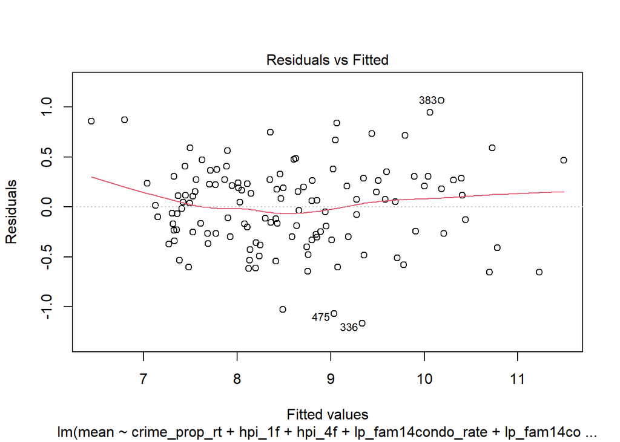

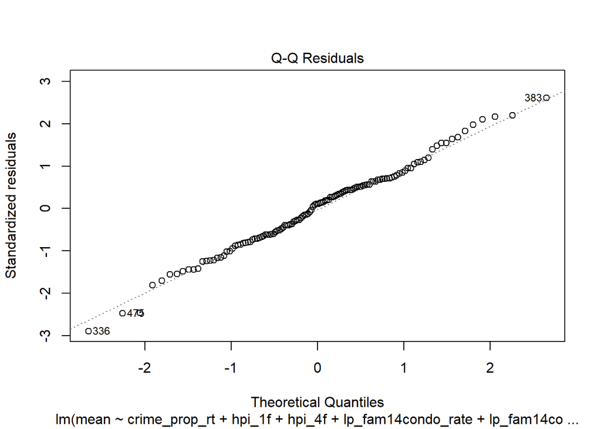

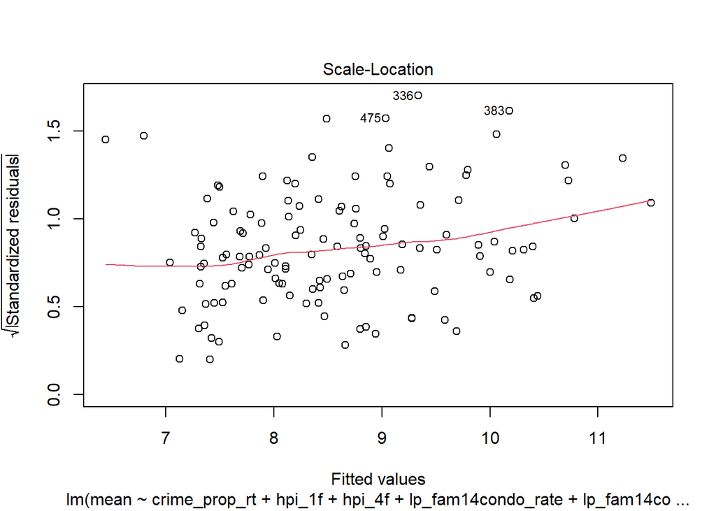

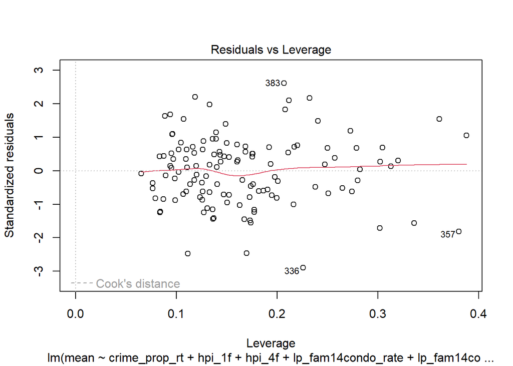

```r
plot(mod_brooklyn)
```

From the looks of it, Queens appears to be a little bit less normal in terms of its distribution. The highest three points on the QQ-Norm plot appear to be much less evenly distributed with the rest of the residuals. However, there appear to be more disconnects starting from the top 15 residuals. Even when I tried removing one significantly abnormal point from the graph, there were still plenty of abnormalities in the data. Thus, this model does not appear to be the best fit for Queens.

```r
mod_queens <- lm(mean ~ crime_prop_rt + crime_viol_rt + hpi_1f + hpi_al + hpi_cn + lp_all + med_r_1f + med_r_cn + pct_prof_ela + pfn_fam14condo + pfn_fam14condo_rate + priv_evic_filing_rt + priv_evic_filings + total_viol_rate + volume_4f + population_density, data = Demo2.5, subset = (Geo.Join.ID > 400 & Geo.Join.ID < 420))
mod_queens_clean <- mod_queens$model[-81,]
mod_queens_clean
```

[output not shown]

[output cut: 373 more lines]